# Capstone Analysis

Caroline Kerwin

18 August 2022

## Bigquery data results

Query:

```r
# Load and clean data
df <- read.csv("bq-results-20220816-175333-1660672444321.csv")
print(paste("Number of rows:", nrow(df)))
```

```
## [1] "Number of rows: 3971588"
```

```r
df$created_at <- ymd_hms(df$created_at)
# Rename field names to conventions


# Drop any rows that do not have a head_repo_id value because there are data errors in these rows and their
# repository cannot be defined
print(paste(nrow(df %>% filter(is.na(head_repo_id))),
      "blank head_repo_ids identified and removed"))
```

```
## [1] "23 blank head_repo_ids identified and removed"
```

```r
df <- df %>% filter(!is.na(head_repo_id))
```

```r
# Get data by repo
count_of_comments <- df %>% count(head_repo_id, sort = TRUE)
# Identify repos with at least 10 comments
over_10_comments <- count_of_comments %>% filter(n >= 10)
data_at_least_10 <- df %>% filter(head_repo_id %in% over_10_comments$head_repo_id)

# Identify repos with at least 3 users
# Filter down to only repos that have 3+ contributors -- enough for a triad to form
users_by_repo <- data_at_least_10 %>% group_by(head_repo_id) %>% summarize(n_distinct(user_id))
over_3_contributors <- users_by_repo[users_by_repo$`n_distinct(user_id)` >= 3,]
data <- data_at_least_10 %>% filter(data_at_least_10$head_repo_id %in% over_3_contributors$head_repo_id)
data$repo_pull_request_id <- paste0(data$head_repo_id, "_", data$pull_request_id)
print(paste("Number of comment actions after filtering:", nrow(data)))
```

```
## [1] "Number of comment actions after filtering: 2609437"
```

```r
print(paste("Number of repositories after filtering:", length(unique(data$head_repo_id))))
```

```
## [1] "Number of repositories after filtering: 27976"
```

```r
# Dataset is too large to do efficient sentiment analysis - use approach outlined in research proposal to create stratified random sample
# Calculate work events per person
actions_per_commit <- data %>% group_by(head_repo_id) %>% count(commit_id)
actions_per_repo <- actions_per_commit %>% count(head_repo_id)
actions_per_repo <- actions_per_repo %>% rename(count_work_events = "n")
users_repo <- data %>% group_by(head_repo_id) %>% summarize(repo_users = n_distinct(user_id))
work_events_data <- users_repo %>% inner_join(actions_per_repo)
work_events_data$work_per_person <- work_events_data$count_work_events / work_events_data$repo_users
work_events_data$productivity <- log(work_events_data$work_per_person)

# Remove data for datapoints where only one user committed to a pull request (no collaboration data)
users_by_repo_pr <- data %>% group_by(repo_pull_request_id) %>% summarize(users_in_pr = n_distinct(user_id))
prs_3_plus_users <- users_by_repo_pr %>% filter(users_in_pr >= 3)
data_multi_users <- data %>% filter(data$repo_pull_request_id %in% prs_3_plus_users$repo_pull_request_id)
print(paste("Number of comment actions after filteringto 3+ user PRs:", nrow(data_multi_users)))
```

```
## [1] "Number of comment actions after filteringto 3+ user PRs: 1666855"
```

```r
# Should be same as above
print(paste("Number of repositories after filtering to 3+ user PRs:", length(unique(data_multi_users$head_repo_id))))
```

```
## [1] "Number of repositories after filtering to 3+ user PRs: 19513"
```

```r
# Assign quartiles to repos
work_events_data <- work_events_data %>% mutate(productivity_quartile = ntile(productivity, 4))

# Get stratified sample of productivity using 4000 repos
work_events_relevant_data <- work_events_data %>% filter(head_repo_id %in% data_multi_users$head_repo_id)
set.seed(5)
stratified_repos <- work_events_relevant_data %>%
  group_by(productivity_quartile) %>%
  sample_n(size = 1000)
```

```r
# Filter overall dataframe to stratified random sample of repositories
data_multi_sample <- data_multi_users %>% filter(head_repo_id %in% stratified_repos$head_repo_id)

write.csv(data_multi_sample, "data_multi_sample.csv")
```

```r
# DownloadSenti4SD()
# model <- Senti4SDModel()
#
# # Run Senti4SD Classifier
# data_multi_sample_results <- Senti4SD(data_multi_sample$commit_comment_body, model)
# data_multi_sample$results <- data_multi_sample_results$polarity
# data_multi_sample %>% count(results)
# write.csv(data_multi_sample, "data_multi_sample_senti_results.csv")
```

```r
# Load in classified data
data_senti <- read.csv("data_multi_sample_senti_results.csv") %>% subset(select = -c(X, ...1))
data_senti$created_at <- ymd_hms(data_senti$created_at)
data_senti_wide <- data_senti %>% group_by(head_repo_id) %>% count(results) %>%
  pivot_wider(names_from = results, values_from = n)

# R will default to autopopulating repos with zero positive/negative comments (i.e. entirely
# neutral) as NAs -- change this to zeros
data_senti_wide[is.na(data_senti_wide)] = 0

# Get proportions of positive and negative content
data_senti_pos_or_neg_all <- data_senti_wide
data_senti_pos_or_neg_all$positive_n <- data_senti_pos_or_neg_all$positive + data_senti_pos_or_neg_all$neutral

data_senti_pos_or_neg_all <- data_senti_pos_or_neg_all %>% subset(
  select = -c(neutral, positive))
data_senti_pos_or_neg_all$total <- data_senti_pos_or_neg_all$negative + data_senti_pos_or_neg_all$positive_n
data_senti_pos_or_neg_all <- data_senti_pos_or_neg_all %>% rename(positive = positive_n)
data_senti_pos_or_neg_all$percent_positive <- data_senti_pos_or_neg_all$positive /
  data_senti_pos_or_neg_all$total
data_senti_pos_or_neg_all$percent_negative <- data_senti_pos_or_neg_all$negative /
  data_senti_pos_or_neg_all$total
data_senti_pos_or_neg <- data_senti_pos_or_neg_all

print(head(data_senti_pos_or_neg))
```

```
## # A tibble: 6 × 6
## # Groups:   head_repo_id [6]
##   head_repo_id negative positive total percent_positive percent_negative
##          <int>    <int>    <int> <int>            <dbl>            <dbl>
## 1            6       84      412   496            0.831           0.169
## 2          136        0        3     3            1               0
## 3          168        3       54    57            0.947           0.0526
## 4          202       14       88   102            0.863           0.137
## 5          231       17       63    80            0.788           0.212
## 6          284        8       64    72            0.889           0.111
```

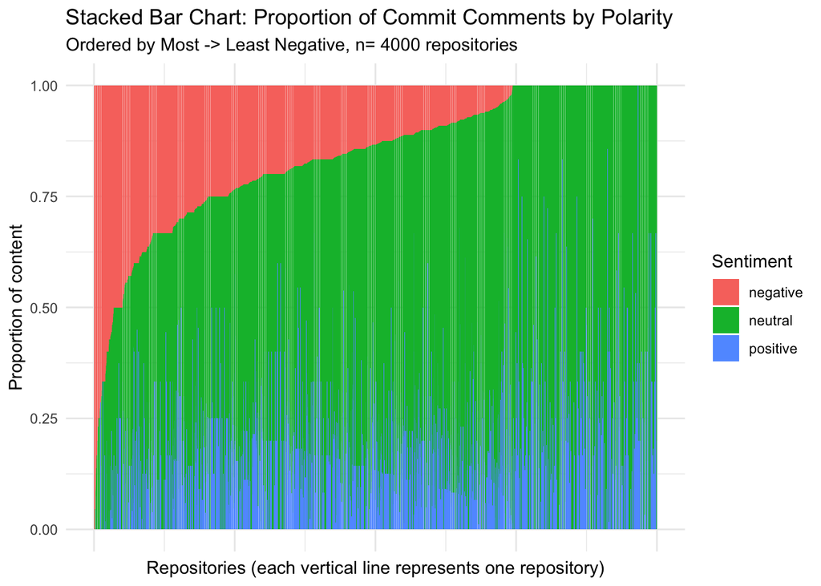

```r
# Plot: proportions of comment polarity in  repos
data_senti_res_long <- data_senti %>% group_by(head_repo_id) %>% count(results)
data_senti_pos_or_neg_all_order <- data_senti_pos_or_neg_all[,c(1,6)] %>% arrange(desc(percent_negative))
data_senti_pos_or_neg_all_order$order <- 1:nrow(data_senti_pos_or_neg_all_order)

data_senti_res_long$neg_order <- sapply(X = data_senti_res_long$head_repo_id,
        FUN = function(repo_id) as.double(
        data_senti_pos_or_neg_all_order[data_senti_pos_or_neg_all_order$head_repo_id == repo_id,3]))

ggplot(data_senti_res_long, aes(fill = results, y = n, x = neg_order)) +
  geom_bar(position = "fill", stat = "identity") +
  labs(title = "Stacked Bar Chart: Proportion of Commit Comments by Polarity",
       subtitle = paste("Ordered by Most -> Least Negative, n=", length(unique(data_senti_res_long$head_repo_id)),
                        "repositories"),
       x = "Repositories (each vertical line represents one repository)",
       y = "Proportion of content") +
  scale_fill_discrete(name = "Sentiment") +
  theme(plot.title = element_text(hjust = 0.5)) +
  theme_minimal() +
  theme(axis.text.x = element_blank(),
        axis.ticks.x = element_blank())
```

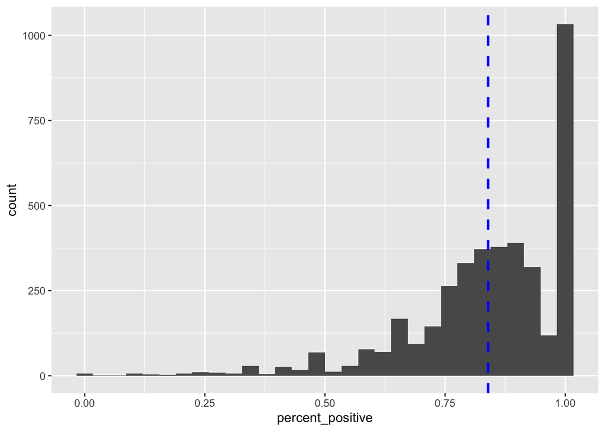

```r
# Check for distribution in variables of interest
# Percent positive
ggplot(data_senti_pos_or_neg, aes(x = percent_positive)) +
  geom_histogram() +
  geom_vline(aes(xintercept = mean(percent_positive)),
            color="blue", linetype="dashed", size=1)
```

```r
# Confirm findings with a Shapiro-Wilk test
# Write a function to check for normality and print results
shapiro_wilk_test <- function(column){
  # Runs a Shapiro-Wilk test and notifies the user of whether the null hypothesis
  # rejected (data not normally distributed) or not (data normally distributed) at the 0.05 level.
  result <- shapiro.test(column)
  print(result)
  if(result$p.value >= 0.5){
    print("We fail to reject the null hypothesis. The data appear to be normally distributed.")
  }
  else{
    print("We reject the null hypothesis. The data do not appear to be normally distributed.")
  }
}

shapiro_wilk_test(data_senti_pos_or_neg$percent_positive)
```

```
##
##  Shapiro-Wilk normality test
##
## data:  column
## W = 0.85763, p-value < 0.00000000000000022
##
## [1] "We reject the null hypothesis. The data do not appear to be normally distributed."
```

## Network Analysis

#### Functions to Run Analysis

```r
# Assign signs by mode of communication sentiment
# Define a function that calculates the mode (excluding zeros)
# If multiple values appear the mode number of times, takes the first
find_mode <- function(x) {
  u <- unique(x)
  u <- u[!u == 0]
  tab <- tabulate(match(x, u))

  if(length(u[tab == max(tab)]) == 2){
    return(u[tab == max(tab)][1])
  }
  else{
    return(u[tab == max(tab)])
  }
}

get_edges <- function(dataset, repo_id){
  # Given a repo ID, returns a dataframe of edges in a bipartite graph with the
  # first column as users and the second column the PRs to which they contributed
  # Dataset here is a df containing data on multiple repos
  ordered_n <- dataset %>% filter(head_repo_id == repo_id) %>% arrange(repo_pull_request_id)
  edges <- ordered_n$user_id %>% as.data.frame() %>% rename(user_id = ".")
  # Sometimes, PRs and users have the same ID number -- eliminate this issue by adding "u_" to users
  edges$user_id <- paste0("u_", edges$user_id)
  edges$repo_pull_request_id <- ordered_n$repo_pull_request_id

  return(edges)
}

get_commit_sentiment <- function(dataset, repo_id){
  # Given a repo_id, returns a vector of the sentiment of each commit comment in the repo
  # Can be combined with get_edges to get the necessary ingredients for signed bipartite
   ordered_n <- dataset %>% filter(head_repo_id == repo_id) %>% arrange(repo_pull_request_id, results)
   results_char <- ordered_n$results %>% as.character()
   results_sign <- replace(results_char, results_char == "negative", -1)
   results_sign <- replace(results_sign, results_sign == "neutral", 1)
   results_sign <- replace(results_sign, results_sign == "positive", 1)
   results_sign <- as.numeric(results_sign)

   return(results_sign)
}

construct_signed_bipartite <- function(edges, signs){
  # Given an edge list (in dataframe format) and a numeric vector of signs,
  # returns a signed bipartite graph
  g <- graph_from_data_frame(edges, directed = FALSE)
  V(g)$type <- V(g)$name %in% edges$user_id
  E(g)$sign <- signs
  return(g)
}

get_signed_digraph <- function(bi_graph){
  # Takes signed bipartite and returns a signed directed graph with edges representing mutual collaboration
  # activities and the sign of edges representing the predominant sentiment a user expressed in mutual PRs
  # Get user-to-user edge list for bipartite in dataframe format:
  edgelist_df <- do.call(
    rbind,
    lapply(
      Filter(
        # Get data by pull request
        function(x) nrow(x) > 1,
        split(get.data.frame(bi_graph), ~to)
      ),
      # Link users in each pull request to one another
      function(d) {
        with(
          d,
          cbind(data.frame(
          # Add edges in one direction
          rbind(t(combn(d$from, 2)),
          # Add edges in other direction
          t(combn(d$from, 2))[,2:1]),
          # Assign PR data to all edges
            pr = unique(d$to)
            )
          )
        )
      }
    )
  )
  edgelist_df <- edgelist_df %>% rename(c(from = "X1", to = "X2"))
  bi_df <- get.data.frame(bi_graph)
  # Assign each user -> PR pair a sign based off of the bipartite graph
  sign_by_user <- rep(0, nrow(edgelist_df))
  for(edge in 1:nrow(edgelist_df)){
    sign_by_user[edge] <- find_mode(bi_df$sign[bi_df$from == edgelist_df$from[edge]
                                     & bi_df$to == edgelist_df$pr[edge]])
  }
  edgelist_df$sign <- sign_by_user
  # For users that have multiple edges (worked on multiple pull requests together), get the most common sign
  mode_sign_df <- edgelist_df %>% group_by(from, to) %>% mutate(mode_sign = find_mode(sign))
  edgelist_unique <- mode_sign_df %>% select(-c(pr, sign)) %>% unique()
  # Set labels for making into graph edge attributes
  edgelist_unique <- edgelist_unique %>% rename(sign = "mode_sign")
  edgelist_unique$color <- ifelse(edgelist_unique$sign == -1, "pink", "blue")

  # Remove self-loop edges since we are focused on collaboration across users
  proj_user_digraph <- simplify(graph_from_data_frame(edgelist_unique, directed = TRUE),
                                 remove.multiple = FALSE, remove.loops = TRUE)
  return(proj_user_digraph)
}

make_flat_signed_proj <- function(dataset, repo_id){
  edges <- get_edges(dataset, repo_id)
  signs <- get_commit_sentiment(dataset, repo_id)
  g <- construct_signed_bipartite(edges, signs)
  multi_proj <- get_signed_digraph(g)

  # Sign of edge will either be -1 or 1; preference for keeping -1
  projection <- as.undirected(multi_proj, mode = "collapse",
                              edge.attr.comb = list(sign = "min", "ignore"))
  return(projection)
}

get_user_senti_balance <- function(projection){
   if(length(E(projection)) > 0){

    balance <- balance_score(projection)
    if(is.nan(balance)){
      result <- "NA - no triangles"
    }
    else{
    result <- balance
    }
  }
  else{
   result <- "NA - no mutual contributions"
  }
  return(result)
}
```

```r
# Run analysis
repos_list <- unique(data_senti$head_repo_id)

# Performing the following calculation generates warnings that are duplicative
# of printed messages -- suppress them:
oldw <- getOption("warn")
options(warn = -1)

repo_network_list <- vector(mode = "list", length = length(repos_list))
repo_balance_scores_u <- rep(0, length(repos_list))
counter <- 1

for(repo in repos_list){
  # Get balance score for each repository
  g <- make_flat_signed_proj(data_senti, repo)
  repo_network_list[[counter]] <- g
  repo_balance_scores_u[counter] <- get_user_senti_balance(g)
  counter <- counter + 1
}

names(repo_network_list) <- repos_list
options(warn = oldw)
```

```r
# These values should all be zero as isolates and dyads not connected to other users were filtered
# out in the data collection process
user_senti_balance_analysis <- repos_list %>% cbind(repo_balance_scores_u)
user_senti_balance_analysis <- user_senti_balance_analysis %>% as.data.frame()
colnames(user_senti_balance_analysis) <- c("repo", "repo_balance_score")

# Is there sufficient heterogeneity in this dataset for analysis?
user_senti_balance_analysis %>% count(repo_balance_score)
```

```
##     repo_balance_score    n
## 1           0.00000000  214
## 2           0.07142857    1
## 3           0.08333333    2
## 4           0.14285714    1
## 5           0.15384615    1
## 6           0.16666667    1
## 7           0.20000000    5
## 8           0.22857143    1
## 9           0.23076923    1
## 10          0.23809524    2
## 11          0.25000000    1
## 12          0.27272727    1
## 13          0.28571429    1
## 14          0.30000000   10
```

[output cut: 362 more lines]

```r
# Number of repositories with no mutual contributions:
no_mutual_contributions <- user_senti_balance_analysis %>%
  filter(repo_balance_score == "NA - no mutual contributions") %>%
  count()
print(no_mutual_contributions[1,])
```

```
## [1] 0
```

```r
# Percentage of repositories with no mutual contributions:
print(no_mutual_contributions[1,] / nrow(user_senti_balance_analysis))
```

```
## [1] 0
```

```r
# Number of repositories with no triangles:
no_triangles <- user_senti_balance_analysis %>%
  filter(repo_balance_score == "NA - no triangles") %>%
  count()
print(no_triangles[1,])
```

```
## [1] 0
```

```r
# Percentage of repositories with no mutual contributions:
print(no_triangles[1,] / nrow(user_senti_balance_analysis))
```

```
## [1] 0
```

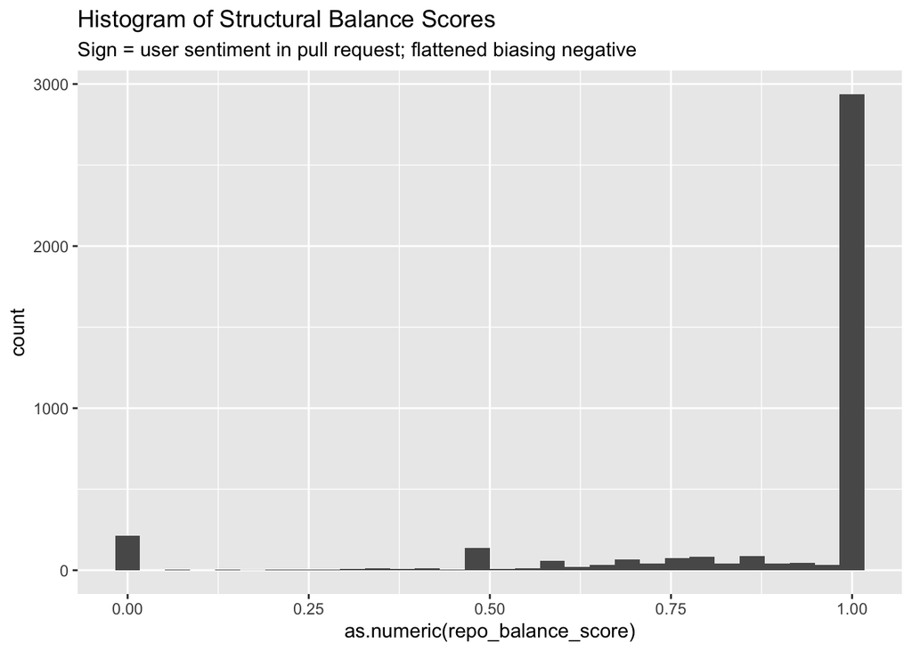

```r
# Plot a histogram of balance scores, excluding repos for which this calculation isn't possible
user_senti_balance_analysis_no_na <- user_senti_balance_analysis %>%
  filter(!repo_balance_score %in% c("NA - no mutual contributions", "NA - no triangles"))

ggplot(user_senti_balance_analysis_no_na, aes(x = as.numeric(repo_balance_score))) +
  geom_histogram() +
  labs(title = "Histogram of Structural Balance Scores",
       subtitle = "Sign = user sentiment in pull request; flattened biasing negative")
```

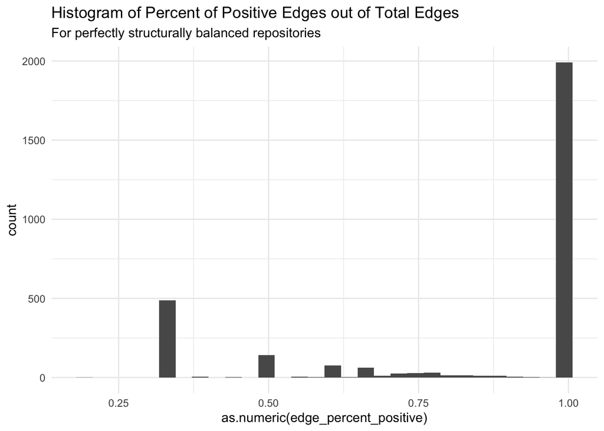

```r
# Let us examine further the data on repositories that are perfectly structurally balanced
balanced <- user_senti_balance_analysis_no_na[user_senti_balance_analysis_no_na$repo_balance_score == 1,]
balanced_repos <- balanced[,1]
# Index only repos that are perfectly balanced
balanced_networks <- repo_network_list[c(as.character(balanced_repos))]

get_positivity_percentage <- function(network){
  edge_signs <- E(network)$sign
  return(sum(edge_signs == 1)/ length(edge_signs))
}

balanced_positivity_percent <- sapply(balanced_networks, get_positivity_percentage)
balanced$edge_percent_positive <- balanced_positivity_percent

ggplot(balanced, aes(x = as.numeric(edge_percent_positive))) +
  geom_histogram() +
  labs(title = "Histogram of Percent of Positive Edges out of Total Edges",
       subtitle = "For perfectly structurally balanced repositories") +
  theme_minimal()
```

A challenge with this analysis is that the vast majority of repositories have a balance score of one.The hypothesis about high structural balance having an adverse effect on collaboration is due to the divisive nature of structurally balanced groups, but this is only the case when there is diverse sentiment. In a perfectly structurally balanced network that is entirely positive, the opposing group is empty. From this description, one would not anticipate adverse effects on collaboration.

In these analyses, we will first look at all repositories to get an overarching view of the sample. We will then remove repositories that have a structural balance score of one due to homogeneous positivity and see if the hypothesis holds true when assuming that there is some level of negativity in the repository.

```r
# Get data on which repositories are fully positive for future analysis
balanced_all_pos <- balanced[balanced$edge_percent_positive >= 1,]
balanced_all_pos$repo <- as.numeric(balanced_all_pos$repo)

# Add in edge positivity data for fully positive networks
data_senti_pos_or_neg <- data_senti_pos_or_neg %>% full_join(
  select(balanced_all_pos,repo, edge_percent_positive), by = c("head_repo_id" = "repo"))
head(data_senti_pos_or_neg)
```

```
## # A tibble: 6 × 7
## # Groups:   head_repo_id [6]
##   head_repo_id negative positive total percent_positive percent_negative
##          <dbl>    <int>    <int> <int>            <dbl>            <dbl>
## 1            6       84      412   496            0.831           0.169
## 2          136        0        3     3            1               0
## 3          168        3       54    57            0.947           0.0526
## 4          202       14       88   102            0.863           0.137
## 5          231       17       63    80            0.788           0.212
## 6          284        8       64    72            0.889           0.111
## # … with 1 more variable: edge_percent_positive <dbl>
```

```r
data_senti_pos_or_neg <- data_senti_pos_or_neg %>% rename(fully_pos_or_not = "edge_percent_positive")

# Populate type
data_senti_pos_or_neg$fully_pos_or_not[is.na(data_senti_pos_or_neg$fully_pos_or_not)] = 0

# Add contributor data
data_senti_pos_or_neg <- data_senti_pos_or_neg %>% inner_join(y = work_events_data, by = "head_repo_id")
data_senti_pos_or_neg <- data_senti_pos_or_neg %>% rename(total_contributors = "repo_users")

# Change type of head_repo_id to numeric to align with joining dataframe
user_senti_balance_analysis_no_na$repo <- as.numeric(user_senti_balance_analysis_no_na$repo)

senti_count_work_events <- data_senti_pos_or_neg %>% subset(select = c(
  head_repo_id, count_work_events, fully_pos_or_not, total_contributors, productivity)) %>%
  inner_join(y = user_senti_balance_analysis_no_na, by = c("head_repo_id" = "repo"))
senti_count_work_events$repo_balance_score <- as.numeric(senti_count_work_events$repo_balance_score)

# Assemble other data for behavioral analysis
# Percent positivity for each repo
# repo_network_list does not have the same order as senti_count_work_events, so data needs to be shuffled
get_positivity_percentage_repo <- function(repo_id){
  network_idx <- repo_network_list[as.character(repo_id)]
  network <- network_idx[1][[1]]
  edge_signs <- E(network)$sign
  return(sum(edge_signs == 1)/ length(edge_signs))
}
senti_count_work_events$positivity_score <-  sapply(senti_count_work_events$head_repo_id,
                                                    get_positivity_percentage_repo)
```

```r
# Create dataset looking exclusively at repositories that are not exclusively positive in communication
data_senti_work_balance_no_full_pos <- senti_count_work_events[
  senti_count_work_events$fully_pos_or_not != 1,]

# Get count of people actually working together in these repositories and not just working on their own
get_vertex_count <- function(repo_id){
  network_idx <- repo_network_list[as.character(repo_id)]
  network <- network_idx[1][[1]]
  count_vertices <- length(V(network))
  return(count_vertices)
}
senti_count_work_events$count_mutual_collaborators <- sapply(senti_count_work_events$head_repo_id, get_vertex_count)
head(senti_count_work_events)
```

```
## # A tibble: 6 × 8
## # Groups:   head_repo_id [6]
##   head_repo_id count_work_events fully_pos_or_not total_contributo… productivity
##          <dbl>             <int>            <dbl>             <int>        <dbl>
## 1            6                55                0                58      -0.0531
## 2          136                 5                1                 6      -0.182
## 3          168                14                0                17      -0.194
## 4          202               134                1                71       0.635
## 5          231                17                0                 9       0.636
## 6          284                47                0                44       0.0660
## # … with 3 more variables: repo_balance_score <dbl>, positivity_score <dbl>,
## #   count_mutual_collaborators <int>
```

## Research Questions:

#### Do repositories exhibit heterogeneous structrual balance?

Many of the perfectly structurally balanced repositories are such because they are entirely positive in their communications. However, some of the perfectly structurally balanced repositories have some heteorgeneity in sentiment. To what extent is this because the edges in triangles are all positive? Does structural balance in triangles within a repo exist in any form other than total positivity?

```r
# How many repos are perfectly structurally balanced?
balanced_count <- length(repo_balance_scores_u[repo_balance_scores_u >= .99999])
print(paste("Number of perfectly balanced repositories:", balanced_count))
```

```
## [1] "Number of perfectly balanced repositories: 2933"
```

```r
print(paste("Percentage of repos that are perfectly balanced:",
            balanced_count / length(repo_balance_scores_u)))
```

```
## [1] "Percentage of repos that are perfectly balanced: 0.73325"
```

```r
triangle_df <- data.frame(matrix(ncol = 5, nrow = 0))
triangle_headings <- c("repo", "+++", "++-", "+--", "---")
colnames(triangle_df) <- triangle_headings

get_triangles_repo <- function(repo_id){
  network_idx <- repo_network_list[as.character(repo_id)]
  network <- network_idx[1][[1]]
  return(count_signed_triangles(network))
}

triangle_list <- lapply(senti_count_work_events$head_repo_id, get_triangles_repo)

counter <- 1
for(repo in triangle_list){
  triangle_df[counter, 1] <- senti_count_work_events$head_repo_id[counter]
  triangle_df[counter, 2] <- triangle_list[[counter]][1][[1]]
  triangle_df[counter, 3] <- triangle_list[[counter]][2][[1]]
  triangle_df[counter, 4] <- triangle_list[[counter]][3][[1]]
  triangle_df[counter, 5] <- triangle_list[[counter]][4][[1]]
  counter <- counter + 1
}

triangle_df$repo <- as.factor(triangle_df$repo)
triangle_df <- triangle_df %>% rowwise() %>%
  dplyr::mutate(all_positive_percent = `+++` / sum(`+++`, `++-`, `+--`, `---`))
triangle_df_order <- triangle_df %>% arrange(desc(all_positive_percent))
triangle_df_order$order <- 1:nrow(triangle_df_order)

triangle_df_long <- triangle_df %>% pivot_longer(names_to = "signs", cols = c(`+++`, `++-`, `+--`, `---`))
triangle_df_long$pos_order <- sapply(X = triangle_df_long$repo,
        FUN = function(repo_id) as.double(
        triangle_df_order[triangle_df_order$repo == repo_id,7]))

# Accounting for the possibility of imprecision in float arithmetic
all_positive_count <- nrow(triangle_df %>% filter(all_positive_percent >= .9999))
repo_count <- nrow(triangle_df)
print("Total structurally balanced repositories with all triangles +++")
```

```
## [1] "Total structurally balanced repositories with all triangles +++"
```

```r
print(all_positive_count)
```

```
## [1] 1992
```

```r
print("Percent of total repos studied that only have positive triads:")
```

```
## [1] "Percent of total repos studied that only have positive triads:"
```

```r
print(all_positive_count / repo_count)
```

```
## [1] 0.498
```

```r
at_least_half_pos_count <-  nrow(triangle_df %>% filter(all_positive_percent > .5))
print("Total structurally balanced repositories with more than half of triangles +++")
```

```
## [1] "Total structurally balanced repositories with more than half of triangles +++"
```

```r
print(at_least_half_pos_count)
```

```
## [1] 2455
```

```r
print("Percent of total repos studied that have at least half positive triads:")
```

```
## [1] "Percent of total repos studied that have at least half positive triads:"
```

```r
print(at_least_half_pos_count / repo_count)
```

```
## [1] 0.61375
```

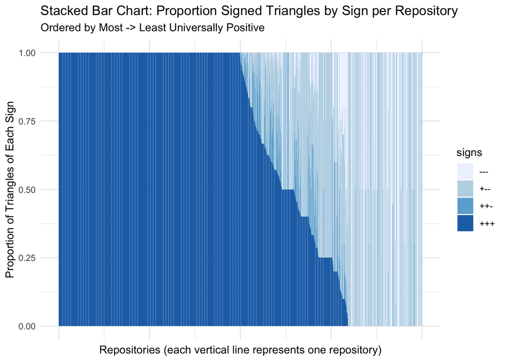

```r
ggplot(triangle_df_long, aes(fill = signs, y = value, x = pos_order)) +
  geom_bar(position = "fill", stat = "identity") +
  scale_fill_brewer() +
  labs(title = "Stacked Bar Chart: Proportion Signed Triangles by Sign per Repository",
       subtitle = "Ordered by Most -> Least Universally Positive",
       x = "Repositories (each vertical line represents one repository)",
       y = "Proportion of Triangles of Each Sign") +
  theme(plot.title = element_text(hjust = 0.5)) +
  theme_minimal() +
  theme(axis.text.x = element_blank(),
        axis.ticks.x = element_blank())
```

```r
total_all_plus <- sum(triangle_df$`+++`)
total_one_neg <- sum(triangle_df$`++-`)
total_two_neg <- sum(triangle_df$`+--`)
total_all_neg <- sum(triangle_df$`---`)
total_triads <- total_all_plus + total_one_neg + total_two_neg + total_all_neg

print(paste("+++ total:", total_all_plus, "Percent of triads:", (total_all_plus / total_triads)))
```

```
## [1] "+++ total: 822950 Percent of triads: 0.59602356427813"
```

```r
print(paste("++- total:", total_one_neg, "Percent of triads:", (total_one_neg / total_triads)))
```

```
## [1] "++- total: 156384 Percent of triads: 0.113261497145721"
```

```r
print(paste("+-- total:", total_two_neg, "Percent of triads:", (total_two_neg / total_triads)))
```

```
## [1] "+-- total: 315443 Percent of triads: 0.228460369629487"
```

```r
print(paste("--- total:", total_all_neg, "Percent of triads:", (total_all_neg / total_triads)))
```

```
## [1] "--- total: 85957 Percent of triads: 0.0622545689466617"
```

```r
# Perfectly structurally balanced and had heterogeneity:
print(paste("Perfectly structurally balanced and had heterogeneity:",
            balanced_count - all_positive_count))
```

```
## [1] "Perfectly structurally balanced and had heterogeneity: 941"
```

```r
print(paste("Percentage of Perfectly structurally balanced and had heterogeneity out of balanced:",
            (balanced_count - all_positive_count) / balanced_count))
```

```
## [1] "Percentage of Perfectly structurally balanced and had heterogeneity out of balanced: 0.320831912717354"
```

```r
print(paste("Percentage of Perfectly structurally balanced and had heterogeneity out of all repos:",
            (balanced_count - all_positive_count) / repo_count))
```

```
## [1] "Percentage of Perfectly structurally balanced and had heterogeneity out of all repos: 0.23525"
```

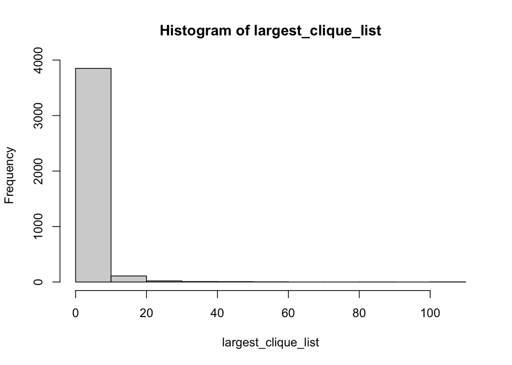

```r
# Descriptive network statistics: find largest cliques
get_cliques_repo <- function(repo_id){
  network_idx <- repo_network_list[as.character(repo_id)]
  network <- network_idx[1][[1]]
  return(clique_num(network))
}

largest_clique_list <- sapply(senti_count_work_events$head_repo_id, get_cliques_repo)
hist(largest_clique_list)
```

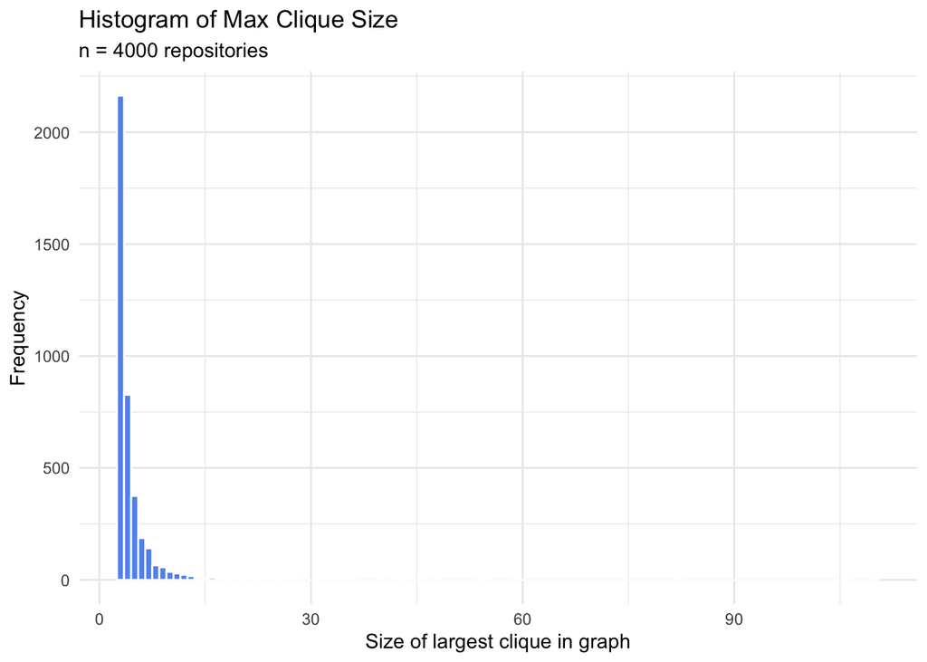

```r
ggplot() +
  aes(x = largest_clique_list) +
  geom_histogram(binwidth = 1, color = "white", fill = "cornflowerblue") +
  labs(fill = "",
       title = "Histogram of Max Clique Size",
       subtitle = paste("n =",
                        length(largest_clique_list), "repositories"),
       x = "Size of largest clique in graph",
       y = "Frequency") +
  theme_minimal()
```

```r
clique_table <- table(largest_clique_list) %>% as.data.frame()
print(clique_table)
```

```
##    largest_clique_list Freq
## 1                    3 2163
## 2                    4  827
## 3                    5  375
## 4                    6  187
## 5                    7  141
## 6                    8   65
## 7                    9   56
## 8                   10   36
## 9                   11   29
## 10                  12   23
## 11                  13   17
## 12                  14    9
## 13                  15    5
## 14                  16   10
```

[output cut: 29 more lines]

```r
clique_deciles <- largest_clique_list %>% as.data.frame() %>% mutate(decile = ntile(largest_clique_list, 10))
clique_deciles <- clique_deciles %>% group_by(decile) %>% summarize(max_cliques_in_decile = max(.))
print(clique_deciles)
```

```
## # A tibble: 10 × 2
##    decile max_cliques_in_decile
##     <int>                 <dbl>
##  1      1                     3
##  2      2                     3
##  3      3                     3
##  4      4                     3
##  5      5                     3
##  6      6                     4
##  7      7                     4
##  8      8                     5
##  9      9                     7
## 10     10                   110
```

Ensuring we are focusing on instances of 3+ collaborators, do we observe structural balance?

```r
triangle_df$max_clique_size <- largest_clique_list
triangle_df$structural_balance_score <- senti_count_work_events$repo_balance_score

# Look exclusively at repos that have a max clique size of 4+
cliques_over_3 <- triangle_df %>% filter(max_clique_size >= 4)
# Total number of repos with largest clique 4+:
count_cliques_over_3 <- nrow(cliques_over_3)
print(count_cliques_over_3)
```

```
## [1] 1837
```

```r
# Percent of large-clique repos with perfect structural balance:
cliques_over_3_balanced <- cliques_over_3 %>% filter(structural_balance_score >= .99999)
count_cliques_over_3_balanced <- nrow(cliques_over_3_balanced)
print(count_cliques_over_3_balanced)
```

```
## [1] 1028
```

```r
print(count_cliques_over_3_balanced / count_cliques_over_3)
```

```
## [1] 0.5596081
```

```r
# Percent of large_clique repos with perfect structural balance AND some non-positive triangles
cliques_over_3_balanced_neg <- cliques_over_3_balanced %>% filter(all_positive_percent < 1)
count_cliques_over_3_balanced_neg <- nrow(cliques_over_3_balanced_neg)
print(count_cliques_over_3_balanced_neg)
```

```
## [1] 380
```

```r
print(count_cliques_over_3_balanced_neg / count_cliques_over_3_balanced)
```

```
## [1] 0.3696498
```

#### Do repositories with a lower structural balance have better collaboration?

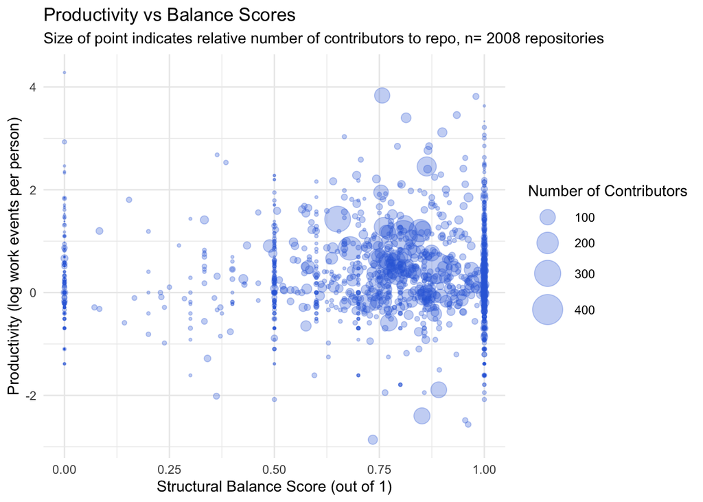

```r
# Flag repos that have no negative edges in triads
all_pos_tri_df <- triangle_df[triangle_df$all_positive_percent >= .9999,]
all_pos_tri_repos <-all_pos_tri_df$repo
senti_work_events_no_full_pos_tri <- senti_count_work_events %>% filter(
  !head_repo_id %in% all_pos_tri_repos)

# Positive triad repos removed
ggplot(senti_work_events_no_full_pos_tri, aes(
  x = repo_balance_score, y = productivity, size = total_contributors)) +
  geom_point(stat = "identity", color = "#356cdb", alpha = 0.3) +
  scale_size(range = c(.01, 10), name = "Number of Contributors") +
  labs(title = "Productivity vs Balance Scores",
       subtitle = paste("Size of point indicates relative number of contributors to repo, n=",
                        nrow(senti_work_events_no_full_pos_tri), "repositories"),
       x = "Structural Balance Score (out of 1)",
       y = "Productivity (log work events per person)") +
  theme_minimal()
```

```r
# Determine if parametric or non-parametric correlation should be used- structural balance:
shapiro.test(senti_work_events_no_full_pos_tri$repo_balance_score)
```

```
##
##  Shapiro-Wilk normality test
##
## data:  senti_work_events_no_full_pos_tri$repo_balance_score
## W = 0.73363, p-value < 0.00000000000000022
```

```r
# Outcome variable:
shapiro.test(senti_count_work_events$productivity)
```

```
##
##  Shapiro-Wilk normality test
##
## data:  senti_count_work_events$productivity
## W = 0.97824, p-value < 0.00000000000000022
```

```r
shapiro.test(senti_work_events_no_full_pos_tri$productivity)
```

```
##
##  Shapiro-Wilk normality test
##
## data:  senti_work_events_no_full_pos_tri$productivity
## W = 0.9729, p-value < 0.00000000000000022
```

```r
# We reject the null hypothesis -> data are not normally distributed -> non-parametric!

# Check for correlations between repo_balance_score and success measures
cor.test(senti_work_events_no_full_pos_tri$repo_balance_score, senti_work_events_no_full_pos_tri$productivity, method = "kendall")
```

```
##
##  Kendall's rank correlation tau
##
## data:  senti_work_events_no_full_pos_tri$repo_balance_score and senti_work_events_no_full_pos_tri$productivity
## z = -3.3016, p-value = 0.0009613
## alternative hypothesis: true tau is not equal to 0
## sample estimates:
##        tau
## -0.0538798
```

```r
print(paste("Number of repositories analysed:", nrow(senti_work_events_no_full_pos_tri)))
```

```
## [1] "Number of repositories analysed: 2008"
```

```r
print(paste("Number of analysed repositories that are perfectly structurally balanced:",
            nrow(senti_work_events_no_full_pos_tri[
              senti_work_events_no_full_pos_tri$repo_balance_score == 1,])))
```

```
## [1] "Number of analysed repositories that are perfectly structurally balanced: 941"
```

```r
nrow(senti_work_events_no_full_pos_tri)
```

```
## [1] 2008
```

#### Does the amount of team collaboration that is positive influence the productivity of a repository?

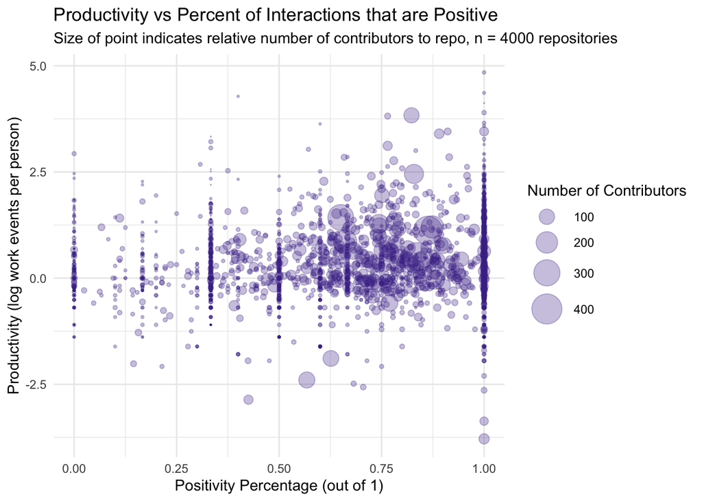

```r
# Positivity and productivity
ggplot(senti_count_work_events, aes(
  x = positivity_score, y = productivity, size = total_contributors)) +
  geom_point(stat = "identity", color = "#4a3396", alpha = 0.3) +
  scale_size(range = c(.01, 10), name = "Number of Contributors") +
  labs(title = "Productivity vs Percent of Interactions that are Positive",
       subtitle = paste("Size of point indicates relative number of contributors to repo, n =",
       nrow(senti_count_work_events), "repositories"),
       x = "Positivity Percentage (out of 1)",
       y = "Productivity (log work events per person)") +
  theme_minimal()
```

```r
# Determine if parametric or non-parametric correlation should be used- positivity:
shapiro.test(senti_count_work_events$positivity_score)
```

```
##
##  Shapiro-Wilk normality test
##
## data:  senti_count_work_events$positivity_score
## W = 0.78466, p-value < 0.00000000000000022
```

```r
# We reject the null hypothesis -> data are not normally distributed -> non-parametric!

# Check for correlations between repo_balance_score and success measures
cor.test(senti_count_work_events$positivity_score, senti_count_work_events$productivity, method = "kendall")
```

```
##
##  Kendall's rank correlation tau
##
## data:  senti_count_work_events$positivity_score and senti_count_work_events$productivity
## z = 3.9442, p-value = 0.00008006
## alternative hypothesis: true tau is not equal to 0
## sample estimates:
##        tau
## 0.04617276
```

```r
# repos analysed:
nrow(senti_count_work_events)
```

```
## [1] 4000
```

#### Can we use characteristics about collaboration within a repo to predict productivity?

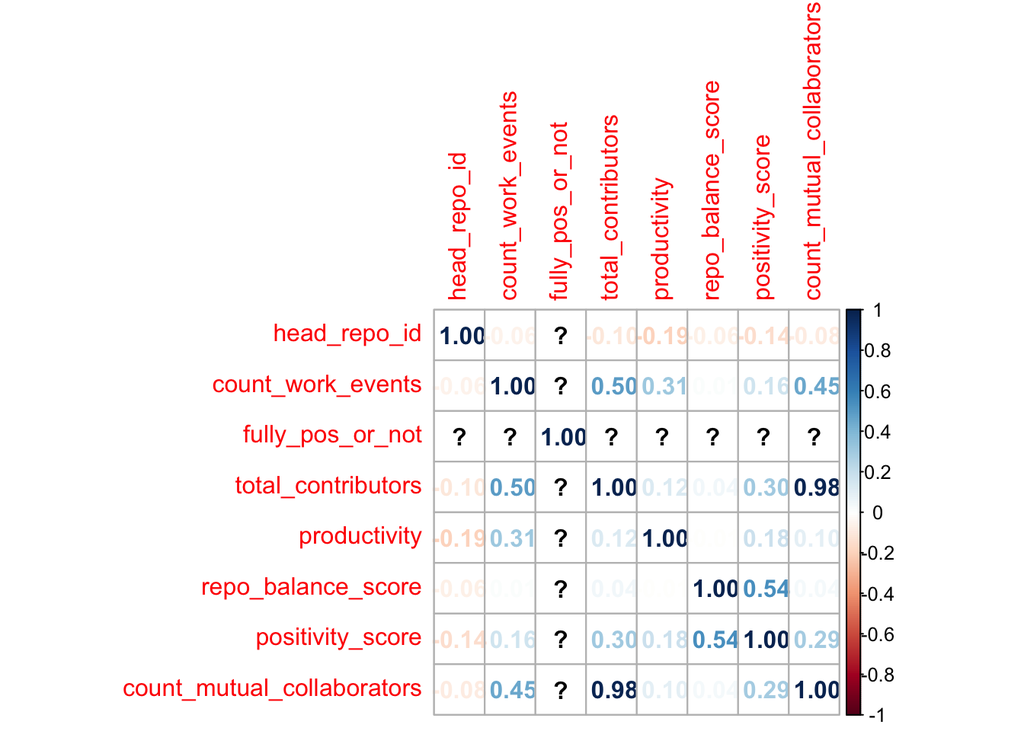

```r
# Before beginning the linear regression, check to see that basic assumptions are met
# Since this analysis looks at structural balance alongside positivity, we want to look at
# only structurally balanced repos that are NOT entirely positive, as this is the hypothesis that
# the study is designed to test regarding structural balance
corrplot(cor(senti_work_events_no_full_pos_tri), method = "number")
```

```r
attach(senti_work_events_no_full_pos_tri)

# Add more network attributes? store and study other network attributes somehow?
mod <- lm(productivity
          ~ total_contributors + positivity_score + repo_balance_score)
summary(mod)
```

```
##
## Call:
## lm(formula = productivity ~ total_contributors + positivity_score +
##     repo_balance_score)
##
## Residuals:
##     Min      1Q  Median      3Q     Max
## -3.0707 -0.4658 -0.0654  0.4321  3.8794
##
## Coefficients:
##                      Estimate Std. Error t value             Pr(>|t|)
## (Intercept)         0.0784227  0.0484351   1.619               0.1056
## total_contributors  0.0020446  0.0008897   2.298               0.0217 *
## positivity_score    0.7854085  0.0876122   8.965 < 0.0000000000000002 ***
## repo_balance_score -0.3750377  0.0679728  -5.517         0.0000000389 ***
## ---
## Signif. codes:  0 '***' 0.001 '**' 0.01 '*' 0.05 '.' 0.1 ' ' 1
##
## Residual standard error: 0.8151 on 2004 degrees of freedom
## Multiple R-squared:  0.05295,    Adjusted R-squared:  0.05153
## F-statistic: 37.35 on 3 and 2004 DF,  p-value: < 0.00000000000000022
```

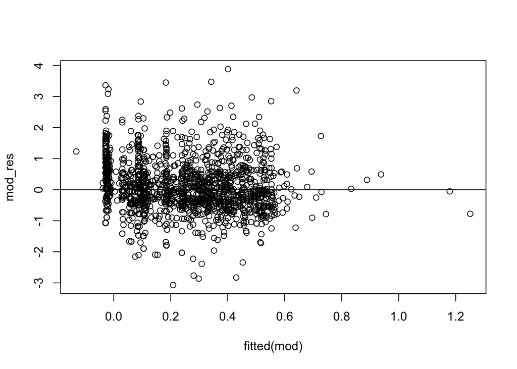

```r
# Plot residuals and QQ plot to check for any concerns with heteroskedasticity
mod_res <- resid(mod)
plot(fitted(mod), mod_res)
abline(0,0)
```

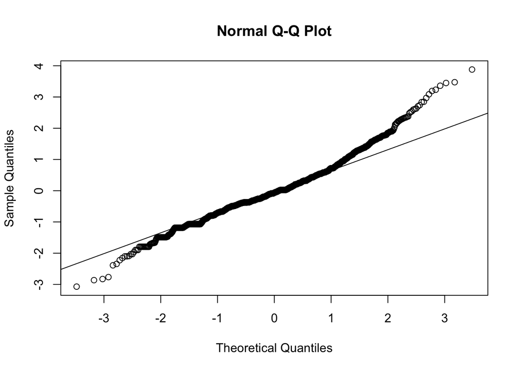

```r
qqnorm(mod_res)
qqline(mod_res)
```

If we focus exclusively on not only the number of people working on a repository but the number of people working together on a repository (removing individuals who did not have mutual contributions with anyone), how does this affect results?

```r
mod_collaborators <- lm(productivity
          ~ count_mutual_collaborators + positivity_score + repo_balance_score)
summary(mod_collaborators)
```

```
##
## Call:
## lm(formula = productivity ~ count_mutual_collaborators + positivity_score +
##     repo_balance_score)
##
## Residuals:
##     Min      1Q  Median      3Q     Max
## -3.0497 -0.4668 -0.0648  0.4317  3.8634
##
## Coefficients:
##                              Estimate Std. Error t value             Pr(>|t|)
## (Intercept)                 0.0842117  0.0484256   1.739               0.0822
## count_mutual_collaborators  0.0011110  0.0009667   1.149               0.2506
## positivity_score            0.8202745  0.0873304   9.393 < 0.0000000000000002
## repo_balance_score         -0.3871690  0.0680189  -5.692         0.0000000144
##
## (Intercept)                .
## count_mutual_collaborators
## positivity_score           ***
## repo_balance_score         ***
## ---
## Signif. codes:  0 '***' 0.001 '**' 0.01 '*' 0.05 '.' 0.1 ' ' 1
##
## Residual standard error: 0.8159 on 2004 degrees of freedom
## Multiple R-squared:  0.05108,    Adjusted R-squared:  0.04966
## F-statistic: 35.96 on 3 and 2004 DF,  p-value: < 0.00000000000000022
```

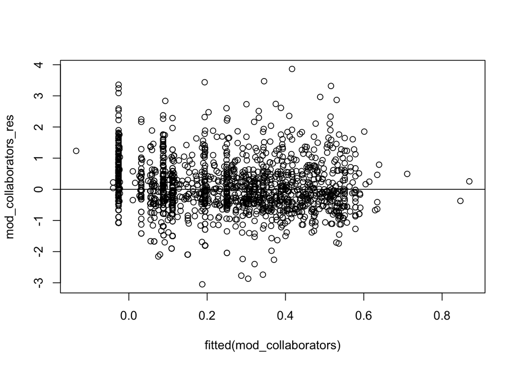

```r
# Plot residuals and QQ plot to check for any concerns with heteroskedasticity
mod_collaborators_res <- resid(mod_collaborators)
plot(fitted(mod_collaborators), mod_collaborators_res)
abline(0,0)
```

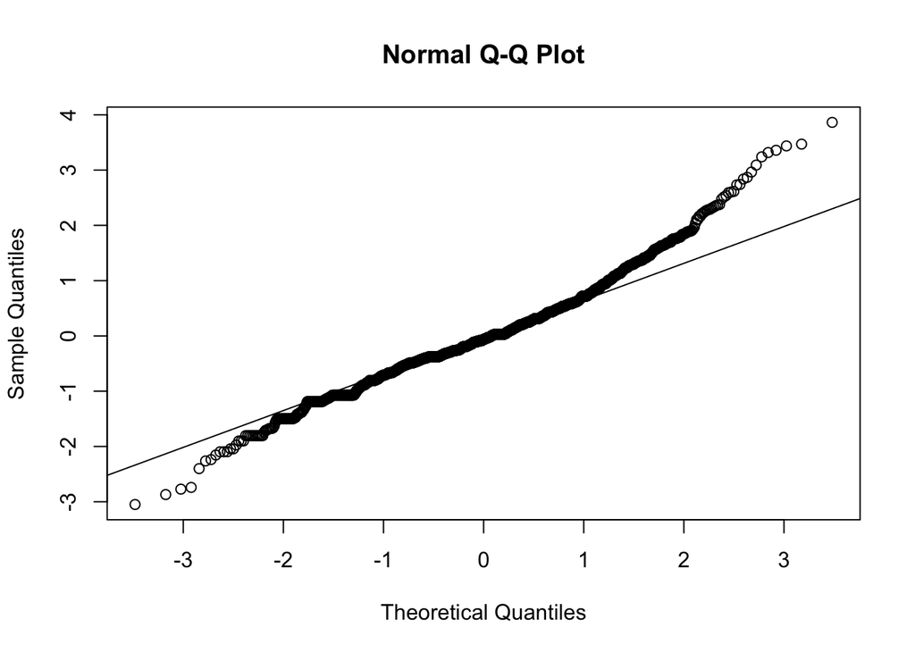

```r
qqnorm(mod_collaborators_res)
qqline(mod_collaborators_res)
```

```r
detach(senti_work_events_no_full_pos_tri)
```